# A Quick and General Way to Identify The Top Associated Variables in a Dataset

[Rama Ramakrishnan](https://mitsloan.mit.edu/faculty/directory/rama-ramakrishnan)

### The Problem

When starting to work with a new dataset, it is useful to quickly identify key relationships in the data. This helps us ask better questions of the data, make better modeling decisions, and ultimately arrive at better answers.

One of the ways to get insight is to pinpoint which pairs of variables appear to be *strongly related*. The [*correlation coefficient*](https://en.wikipedia.org/wiki/Correlation_coefficient) is used widely for this purpose but it is well-known that it can’t detect non-linear relationships. Take a look at this scatterplot of two variables $x$ and $y$.

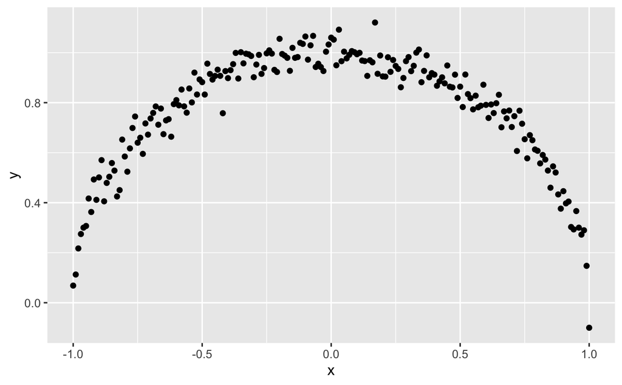

```r
set.seed(42)
x <- seq(-1,1,0.01)
y <- sqrt(1 - x^2) + rnorm(length(x),mean = 0, sd = 0.05)

ggplot(mapping = aes(x, y)) +
  geom_point()
```

It is obvious to the human eye that $x$ and $y$ have a strong relationship but the correlation coefficient between $x$ and $y$ is only -0.01.

Further, if either variable of the pair is *categorical*, we can’t use the correlation coefficient. We will have to turn to other metrics. For example, if $x$ and $y$ are **both** categorical variables, we can try [Cramer’s V](https://en.wikipedia.org/wiki/Cram%C3%A9r%27s_V) or [the phi coefficient](https://en.wikipedia.org/wiki/Phi_coefficient). If $x$ is continuous and $y$ is binary, we can use the [point-biserial correlation coefficient](https://en.wikipedia.org/wiki/Point-biserial_correlation_coefficient)

But using different metrics is problematic. Since they are derived from different assumptions, we can’t **compare the resulting numbers with one another**. If the correlation coefficient between continuous variables $x$ and $y$ is 0.6 and the phi coefficient between categorical variables $u$ and $v$ is also 0.6, can we safely conclude that the relationships are equally strong? According to [Wikipedia](https://en.wikipedia.org/wiki/Phi_coefficient),

> The correlation coefficient ranges from −1 to +1, where ±1 indicates perfect agreement or disagreement, and 0 indicates no relationship. The phi coefficient has a maximum value that is determined by the distribution of the two variables if one or both variables can take on more than two values.

A phi coefficient value of 0.6 between $u$ and $v$ may not mean much if its maximum possible value in this particular situation is much higher. Perhaps we can normalize the phi coefficient to map it to the 0-1 range? But what if that modification introduces biases?

Wouldn’t it be nice if we had **one** approach that was easy to understand, worked for continuous **and** categorical variables alike, and could detect linear **and** nonlinear relationships?

If we had such an approach, given any new dataset, we can calculate the association between all pairs of variables and knowing that the numbers are comparable, we can confidently *sort* them in descending order and identify the top variable pairs.

(BTW, when $x$ and $y$ are continuous, looking at a scatter plot of $x$ vs $y$ can be very effective since the human brain can detect linear and non-linear patterns - distinct groups, lines and curves - very quickly. But even if you are lucky and *all* your variables are continuous, looking at scatterplots of *all* pairs of variables is hard when you have lots of variables in your dataset; with just 100 predictors (say), you will need to look through 4950 scatterplots and this obviously isn’t practical)

### A Potential Solution

To devise a metric that satisfies the requirements we listed above, let’s *invert* the problem: What does it mean to say that $x$ and $y$ **don’t** have a strong relationship?

Intuitively, if there’s no relationship between $x$ and $y$, we would expect to see no patterns in a scatterplot of $x$ and $y$ - no lines, curves, groups etc. It will be a cloud of points that appears to be randomly scattered, perhaps something like this:

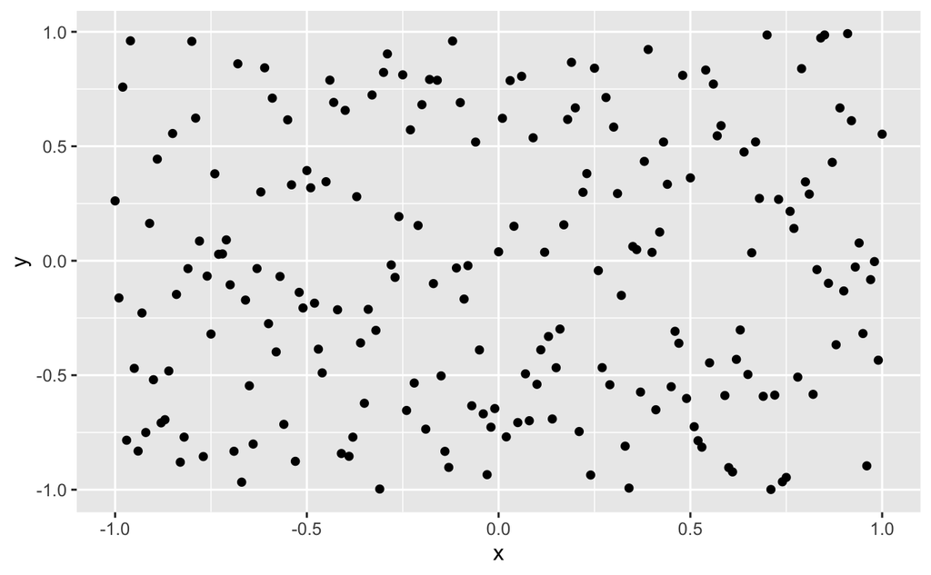

```r
x <- seq(-1,1,0.01)
y <- runif(length(x),min = -1, max = 1)

ggplot(mapping = aes(x, y)) +
  geom_point()
```

In this situation, does knowing the value of $x$ give us any information on $y$?

Clearly not. $y$ seems to be somewhere between -1 and 1 with no particular pattern, regardless of the value of $x$. Knowing $x$ does not seem to help *reduce our uncertainty* about the value of $y$.

In contrast, look at the first picture again.

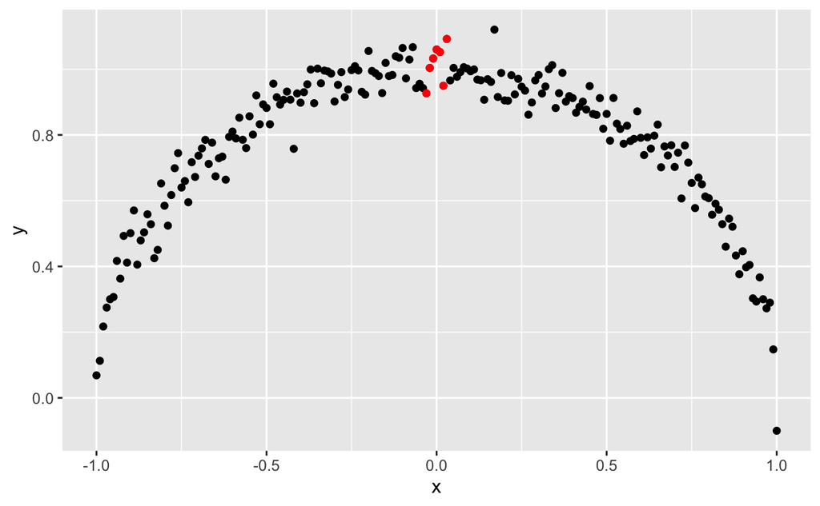

Here, knowing the value of $x$ *does* help. If we know that $x$ is around 0, for example, from the graph we will guess that $y$ is likely just around 1.0 (see the red dots). We can be confident that $y$ is **not** between 0 and 0.8. Knowing $x$ helps us eliminate certain values of $y$ and zero in on others, **reducing our uncertainty** in the values $y$ might take.

This notion - knowing something reduces our uncertainty in something else - is exactly the idea behind [mutual information](https://en.wikipedia.org/wiki/Mutual_information) from [Information Theory](https://en.wikipedia.org/wiki/Information_theory).

According to [Wikipedia](https://en.wikipedia.org/wiki/Mutual_information) (emphasis mine),

> Intuitively, mutual information measures the information that $X$ and $Y$ share: It measures **how much knowing one of these variables reduces uncertainty about the other**. For example, if $X$ and $Y$ are independent, then knowing $X$ does not give any information about $Y$ and vice versa, so their mutual information is zero.

Furthermore,

> **Not limited to real-valued random variables and linear dependence like the correlation coefficient**, MI is more general and determines how different the joint distribution of the pair $(X,Y)$ is to the product of the marginal distributions of $X$ and $Y$.

This is very promising but, as it turns out, implementing it is not so simple. We first need to estimate the joint probabilities (i.e., the joint probability density/mass function) of $x$ and $y$ before we can calculate their Mutual Information. If $x$ and $y$ are categorical, this is easy but if one or both of them is continuous, it is more involved.

But we can use the basic insight behind mutual information – that knowing $x$ may reduce our uncertainty about $y$ – in a different way.

### The X2Y Metric

Consider three variables $x$, $y$ and $z$. Let’s say that knowing $x$ reduces our uncertainty about $y$ by 70% but knowing $z$ reduces our uncertainty about $y$ by only 40% (ignore for a moment how we calculate these numbers). In this scenario, we will intuitively expect that the association between $x$ and $y$ will be stronger than the association between $z$ and $y$.

So, if we can *quantify* the reduction in uncertainty, that can be used as a measure of the strength of the association. One way to do so is to measure $x$’s ability to *predict* $y$ - after all, **if $x$ reduces our uncertainty about $y$, shouldn’t knowing $x$ help us predict $y$ better than if we didn’t know $x$**?

To put it differently, we can think of reduction in prediction error as a quantification of reduction in uncertainty.

This suggests the following approach:

1. Predict $y$ *without using* $x$
2. Predict $y$ *using* $x$
3. Calculate the **% decrease in prediction error** when we go from (1) to (2)

For predicting $y$ without using any other variables, we can simply use the average value of $y$, if $y$ is continuous. If $y$ is categorical, we can use the most frequent value of $y$ (this is sometimes called a *baseline model*).

For predicting $y$ using $x$, we can take any of the standard predictive models out there (Linear/Logistic Regression, CART, Random Forests, SVMs, Neural Networks, Gradient Boosting etc.), set $x$ as the independent variable and $y$ as the dependent variable, fit the model to the data, and make predictions.

How should we measure prediction error?

- If $y$ is continuous, we can use any of the familiar error metrics like RMSE, SSE, MAE etc. I prefer mean absolute error (MAE) since it is less susceptible to outliers and is in the same units as $y$ but this is a matter of personal preference.
- If $y$ is categorical, we can use Misclassification Error (= 1 - Accuracy) as the error metric.

Note that by using the same error metric for both (1) and (2) and calculating the % decrease, we are making the metric *comparable* across variable pairs.

> To summarize, the % reduction in error when we go from a baseline model to a predictive model (of our choosing) measures the strength of the relationship between $x$ and $y$. Let’s call this metric `x2y` since it measures the ability of $x$ to predict $y$.

Which predictive model should we use? Let’s remind ourselves of what the requirements are:

- If there’s a non-linear relationship between $x$ and $y$, the model should be able to detect it
- It should be able to handle all possible $x$-$y$ variable types: continuous-continuous, continuous-categorical, categorical-continuous and categorical-categorical
- We may have hundreds (if not thousands) of pairs of variables we want to analyze so we want this to be quick

[Classification and Regression Trees (CART)](https://en.wikipedia.org/wiki/Decision_tree_learning) satisfies these requirements very nicely and that’s the one I prefer to use. That said, you can certainly use other models if you like.

If you are familiar with how to build a CART model, it is straightforward to implement the `x2y` metric in the Machine Learning environment of your choice. Since it is particularly easy to build CART models in R, I have written a small R script that calculates the `x2y` metric (details in the appendix).

Let’s try this approach on the ‘semicircle’ dataset from above. We fit a CART tree to predict $y$ using $x$ and here’s how the fitted values look:

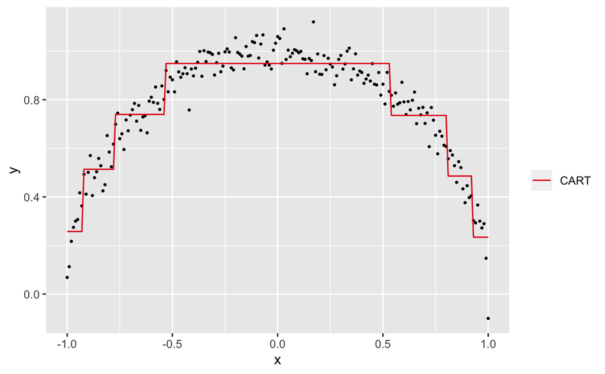

```r
# Let's generate the data again
set.seed(42)
x <- seq(-1,1,0.01)

d <- data.frame(x = x,
                    y = sqrt(1 - x^2) + rnorm(length(x),mean = 0, sd = 0.05))

library(rpart)
preds <- predict(rpart(y~x, data = d, method = "anova"), type = "vector")

# Set up a chart
ggplot(data = d, mapping = aes(x = x)) +
  geom_point(aes(y = y), size = 0.5) +
  geom_line(aes(y=preds, color = '2')) +
  scale_color_brewer(name = "", labels='CART', palette="Set1")
```

The CART predictions do seem to approximate the semi-circular relationship between $x$ and $y$ reasonably well, and as we would hope, the `x2y` metric captures this and comes in at 68.88%. Excellent!

### A Caveat

It is important to understand that, unlike metrics like the correlation coefficient, the `x2y` metric is **not** symmetric with respect to $x$ and $y$. The extent to which $x$ can predict $y$ can be different from the extent to which $y$ can predict $x$. For the semi-circle dataset, `x2y(x,y)` is 68.88% but `x2y(y,x)` is only 10.2%.

This shouldn’t come as a surprise, however. Let’s look at the scatterplot again but with the axes reversed.

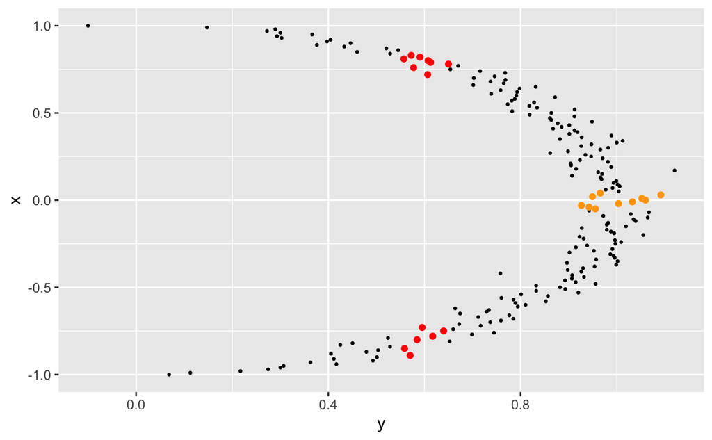

```r
ggplot(data = d, mapping = aes(x = y)) +
  geom_point(aes(y = x), size = 0.5)  +
  geom_point(data = d[abs(d$x) < 0.05,], aes(x = y, y = x), color = "orange" ) +
  geom_point(data = d[abs(d$y-0.6) < 0.05,], aes(x = y, y = x), color = "red" )
```

All this said, if you *must* have a symmetric metric for your application, you can just take the average of `x2y(x,y)` and `x2y(y,x)`.

### Application to the Iris Dataset

The [`iris` dataset](https://en.wikipedia.org/wiki/Iris_flower_data_set) is iconic in the statistics/ML communities and is widely used to illustrate basic concepts. The dataset consists of 150 observations in total and each observation has four continuous variables - the length and the width of the petals and sepals - and a categorical variable indicating the species of Iris.

Let’s take a look.

```r
iris %>% sample_n(10) %>% pander
```

```
----------------------------------------------------------------------
 Sepal.Length   Sepal.Width   Petal.Length   Petal.Width    Species
-------------- ------------- -------------- ------------- ------------
      6             2.7           5.1            1.6       versicolor

      6             2.2            5             1.5       virginica

      5             3.4           1.5            0.2         setosa

     5.7             3            4.2            1.2       versicolor

     7.4            2.8           6.1            1.9       virginica

     6.5             3            5.8            2.2       virginica

     6.4            2.9           4.3            1.3       versicolor

     6.7            3.1           5.6            2.4       virginica

     7.1             3            5.9            2.1       virginica

     5.1            3.5           1.4            0.3         setosa
----------------------------------------------------------------------
```

Now, let’s run it through the `x2y` calculation.

```r
all_pairs_x2y(iris) %>% pander
```

```
---------------------------------------------------
      x              y          x2y    perc_of_obs
-------------- -------------- ------- -------------
 Petal.Width      Species       94         100

 Petal.Length     Species       93         100

 Petal.Width    Petal.Length   80.73       100

   Species      Petal.Length   79.72       100

 Petal.Length   Petal.Width    77.32       100

   Species      Petal.Width    76.31       100

 Sepal.Length   Petal.Length   66.88       100

 Sepal.Length     Species       62         100

 Petal.Length   Sepal.Length   60.98       100

 Sepal.Length   Petal.Width    54.36       100

 Petal.Width    Sepal.Length   48.81       100

   Species      Sepal.Length   42.08       100

 Sepal.Width      Species       39         100

 Petal.Width    Sepal.Width    31.75       100

 Petal.Length   Sepal.Width     30         100

 Sepal.Width    Petal.Length   28.16       100

 Sepal.Width    Petal.Width    23.02       100

   Species      Sepal.Width    22.37       100

 Sepal.Length   Sepal.Width    18.22       100

 Sepal.Width    Sepal.Length   12.18       100
---------------------------------------------------
```

The output has four columns:

- The $x$ variable
- The $y$ variable
- The `x2y` metric
- `perc_of_obs` has the % of observations in the dataframe that was used to calculate that row’s `x2y` value. When a dataset has missing values, only observations that have values present for both $x$ and $y$ will be used to calculate the `x2y` metrics for that variable pair. The `iris` dataset has no missing values so this value is 100 for all rows.

The results are sorted in descending order of the `x2y` value. But since this is just a standard dataframe, it can be sliced, sorted, filtered, plotted etc.

Looking at the numbers, both `Petal.Length` and `Petal.Width` seem to be highly associated with each other and with `Species`. In contrast, it appears that `Sepal.Length` and `Sepal.Width` are very weakly associated with each other.

Note that even though `Species` is categorical and the other four variables are continuous, we were able to calculate the pairwise associations and compare them easily.

### Application to a COVID-19 Dataset

Next, we examine a [COVID-19 dataset](https://github.com/mdcollab/covidclinicaldata/blob/master/data/04-14_carbonhealth_and_braidhealth.csv). This dataset contains clinical characteristics and COVID-19 test outcomes for 352 patients. Since it has a good mix of continuous and categorical variables, having something like the `x2y` metric that can work for any type of variable pair is especially convenient.

Let’s read in the data and take a quick look at the columns.

```r
df <- read.csv("covid19.csv", stringsAsFactors = FALSE)
str(df)
```

```
'data.frame':   352 obs. of  45 variables:
 $ date_published               : chr  "2020-04-14" "2020-04-14" "2020-04-14" "2020-04-14" ...
 $ clinic_state                 : chr  "CA" "CA" "CA" "CA" ...
 $ test_name                    : chr  "Rapid COVID-19 Test" "Rapid COVID-19 Test" "Rapid COVID-19 Test" "Rapid COVID-19 Test" ...
 $ swab_type                    : chr  "" "Nasopharyngeal" "Nasal" "" ...
 $ covid_19_test_results        : chr  "Negative" "Negative" "Negative" "Negative" ...
 $ age                          : int  30 77 49 42 37 23 71 28 55 51 ...
 $ high_risk_exposure_occupation: logi  TRUE NA NA FALSE TRUE FALSE ...
 $ high_risk_interactions       : logi  FALSE NA NA FALSE TRUE TRUE ...
 $ diabetes                     : logi  FALSE FALSE FALSE FALSE FALSE FALSE ...
 $ chd                          : logi  FALSE FALSE FALSE FALSE FALSE FALSE ...
 $ htn                          : logi  FALSE TRUE FALSE TRUE FALSE FALSE ...
 $ cancer                       : logi  FALSE FALSE FALSE FALSE FALSE FALSE ...
 $ asthma                       : logi  TRUE TRUE FALSE TRUE FALSE FALSE ...
 $ copd                         : logi  FALSE FALSE FALSE FALSE FALSE FALSE ...
```

[output cut: 31 more lines]

There are lots of missing values (denoted by ‘NA’) and lots of blanks as well - for example, see the first few values of the `rapid_flu_results` field above. We will convert the blanks to NAs so that all the missing values can be treated consistently. Also, the rightmost three columns are free-text fields so we will remove them from the dataframe.

```r
df <- read.csv("covid19.csv",
                  stringsAsFactors = FALSE,
                  na.strings=c("","NA") # read in blanks as NAs
                  )%>%
  select(-starts_with("cxr"))  # remove the chest x-ray note fields

str(df)
```

```
'data.frame':   352 obs. of  42 variables:
 $ date_published               : chr  "2020-04-14" "2020-04-14" "2020-04-14" "2020-04-14" ...
 $ clinic_state                 : chr  "CA" "CA" "CA" "CA" ...
 $ test_name                    : chr  "Rapid COVID-19 Test" "Rapid COVID-19 Test" "Rapid COVID-19 Test" "Rapid COVID-19 Test" ...
 $ swab_type                    : chr  NA "Nasopharyngeal" "Nasal" NA ...
 $ covid_19_test_results        : chr  "Negative" "Negative" "Negative" "Negative" ...
 $ age                          : int  30 77 49 42 37 23 71 28 55 51 ...
 $ high_risk_exposure_occupation: logi  TRUE NA NA FALSE TRUE FALSE ...
 $ high_risk_interactions       : logi  FALSE NA NA FALSE TRUE TRUE ...
 $ diabetes                     : logi  FALSE FALSE FALSE FALSE FALSE FALSE ...
 $ chd                          : logi  FALSE FALSE FALSE FALSE FALSE FALSE ...
 $ htn                          : logi  FALSE TRUE FALSE TRUE FALSE FALSE ...
 $ cancer                       : logi  FALSE FALSE FALSE FALSE FALSE FALSE ...
 $ asthma                       : logi  TRUE TRUE FALSE TRUE FALSE FALSE ...
 $ copd                         : logi  FALSE FALSE FALSE FALSE FALSE FALSE ...
```

[output cut: 28 more lines]

Now, let’s run it through the `x2y` approach. We are particularly interested in associations between clinical characteristics and the `covid_19_test_results` field so we select only those rows where `covid_19_test_results` is either $x$ or $y$ and the `x2y` value is greater than zero.

```r
results <- all_pairs_x2y(df)
results %>%
  filter(x == "covid_19_test_results" |
         y == "covid_19_test_results" ) %>%
  filter(x2y > 0) %>%
  pander
```

```
-------------------------------------------------------------
           x                   y          x2y    perc_of_obs
----------------------- --------------- ------- -------------
 covid_19_test_results   loss_of_smell   18.18      21.88

 covid_19_test_results   loss_of_taste   12.5       22.73

 covid_19_test_results       sats        2.24       92.9
-------------------------------------------------------------
```

Unfortunately, only *three* of the 41 variables have a non-zero association with `covid_19_test_results`. Disappointingly, the highest `x2y` value is an unimpressive 18% and it is based on just 22% of the observations (since the other 78% of observations had missing values). That said, it is interesting that `loss_of_smell` and `loss_of_taste` are the most associated with `covid_19_test_results` in this dataset since they are on the [list of COVID-19 symptoms highlighted by the CDC](https://www.cdc.gov/coronavirus/2019-ncov/symptoms-testing/symptoms.html).

Let’s see what the top 10 assocations are, between *any* pair of variables.

```r
results %>% head(10) %>% pander
```

```
-----------------------------------------------------
       x               y          x2y    perc_of_obs
--------------- --------------- ------- -------------
 loss_of_smell   loss_of_taste    100       20.17

 loss_of_taste   loss_of_smell    100       20.17

    fatigue        headache      90.91      40.06

   headache         fatigue      90.91      40.06

    fatigue       sore_throat    89.58      27.84

   headache       sore_throat    89.36      30.4

  sore_throat       fatigue      88.89      27.84

  sore_throat      headache      88.64      30.4

  runny_nose        fatigue      84.44      25.57

  runny_nose       headache      84.09      25.57
-----------------------------------------------------
```

Interesting. `loss_of_smell` and `loss_of_taste` are *perfectly* associated with each other, suggesting that they agree for *every* observation in the dataset for which their values are available. Let’s check this.

```r
df %>%
  filter(!is.na(loss_of_smell),
         !is.na(loss_of_taste)) %>%
  count(loss_of_smell,loss_of_taste) %>%
  pander
```

```
------------------------------------
 loss_of_smell   loss_of_taste   n
--------------- --------------- ----
     FALSE           FALSE       55

     TRUE            TRUE        16
------------------------------------
```

Yes, they are identical as we suspected.

Moving down the `x2y` ranking, we see a number of variables - `fatigue`, `headache`, `sore_throat`, and `runny_nose` - that are *all strongly associated with each other*, as if they are all connected by a common cause. Perhaps they are, but we should be careful about drawing any conclusions from these numbers since they are based on just 20-40% of observations.

When the number of variable combinations is high and there are lots of missing values, it can be helpful to scatterplot `x2y` vs `perc_of_obs`.

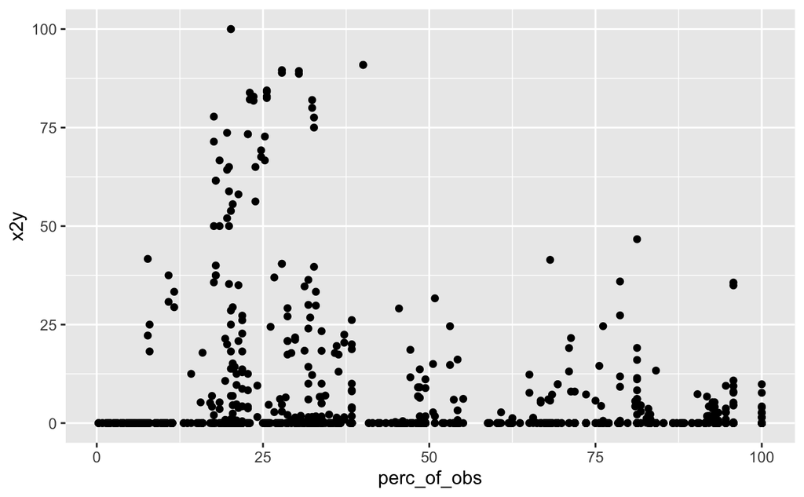

```r
ggplot(data = results, aes(y=x2y, x = perc_of_obs)) +
         geom_point()
```

Two aspects jump out:

- When more observations are available for the `x2y` calculation (i.e. fewer observations are missing), the `x2y` values tend to be lower.
- The top-right quadrant is empty: there are no variable pairs with a higher than 50% `x2y` value that are based on at least 50% of the observations.

### Conclusion

Using an insight from Information Theory, we devised a new metric - the `x2y` metric - that quantifies the strength of the association between pairs of variables.

The `x2y` metric has several advantages:

- It works for all types of variable pairs (continuous-continuous, continuous-categorical, categorical-continuous and categorical-categorical)
- It captures linear and non-linear relationships
- Perhaps best of all, it is easy to understand and use.

I hope you give it a try in your work.

(If you found this note helpful, you may find [these](https://rama100.github.io/lecture-notes/) of interest)

### Appendix: How to use the R script

The R script depends on two R packages - `rpart` and `dplyr` - so please ensure that they are installed in your environment.

The script has two key functions: `x2y()` and `all_pairs_x2y()`.

For variables $u$ and $v$, `x2y(u,v)` returns the `x2y` metric for using $u$ to predict $v$.

For a dataframe $d$ with $n$ columns , `all_pairs_x2y(d)` returns a dataframe with: